# 1 ggPlot2

## 2.3 Estadísticos

La transformaciones estadísticas de los datos, o *stat*, resume los valores estadísticos de los datos. Para realizar estas transformaciones estadísticas, se añade una capa con las funciones `stat_...()` En el siguiente ejemplo, se modifica el número de cajas de un histograma:

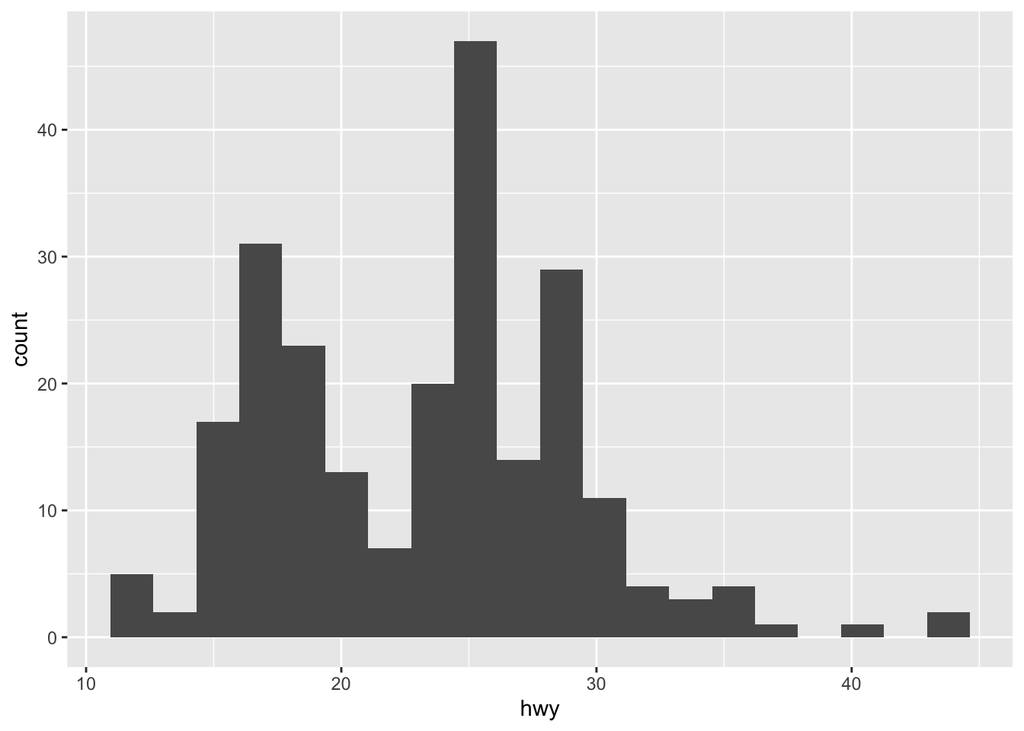

```r
##Codigo para crear un histograma con un número de cajas de 30
ggplot(mpg, aes(x = hwy)) +
  geom_histogram()
##Con la función stat_bin se modifica el número de cajas a 20
ggplot(mpg, aes(x = hwy)) +
  stat_bin(bins = 20)
```

Adicionalmente, con las funciones `stat` se calculan valores como la media de alguna variable y se grafica. En el siguiente ejemplo se calcula la media de *hwy* usando la función **`stat_summary()`**:

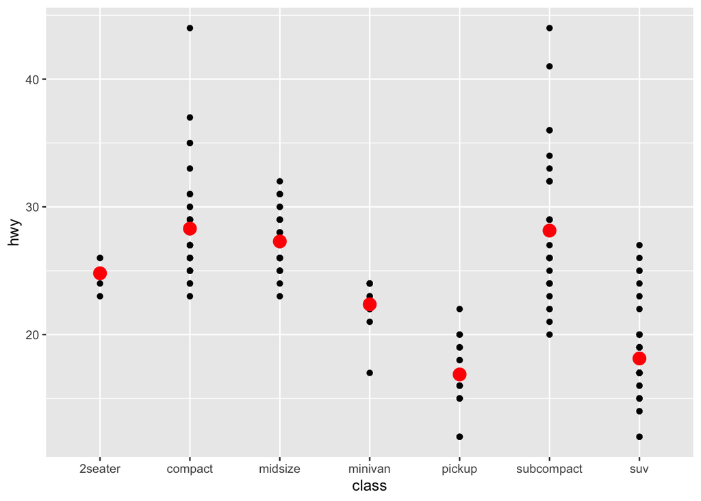

```r
##Transformar los datos calculando y añadiendo la media del Sepal.Length
ggplot(mpg, aes(x = class, y = hwy)) +
  geom_point() +
  stat_summary(geom = "point", fun = "mean", color = "red", size = 4)
```

Finalmente, las transformaciones estadísticas permiten añadir líneas de tendencia para análisis de regresión. La función `stat_smooth()` añade una linea de tendencia en gráficos de puntos para dos variables continuas:

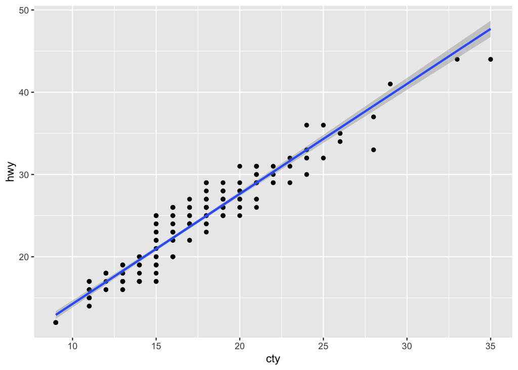

```r
##Añadir una línea de tendencia a un gráfico de puntos
ggplot(mpg, aes(x = cty, y = hwy)) +
  geom_point() +
  stat_smooth(geom = "smooth", method = "lm")
```

La variedad de transformaciones estadísiticas que se pueden realizar alos gráficos de ggplot2 las puedes consultar en https://ggplot2-book.org/statistical-summaries.

## 2.4 Escalas

Las escalas en **`ggplot2`** controlan los valores estéticos de una gráfica. En otras palabras, convierten los valores de las variables de los datos en algo graficable como el color, la forma, el tamaño o la posición.

Las escalas se dividen en tres categorías: - Escalas de posición y ejes - Escalas de color y leyendas - Escalas para tamaño, forma, grosor y tipo de figuras

### 2.4.1 Escalas de posición y ejes

Las escalas de posición y ejes controlan la localización de los elementos visuales de una gráfica. En el caso de gráficos en dos dimensiones, existen dos escalas correspondientes a los elementos en los ejes x y. Para variables contínuas, ggplot utiliza por default las funciones `scale_x_continous()` y `scale_y_continous()` para graficar de forma lineal ambos ejes. Sin embargo, existen otro tipos de escalas y transformaciones como `scale_x_log10()` la cual transforma logaritmicamente los datos:

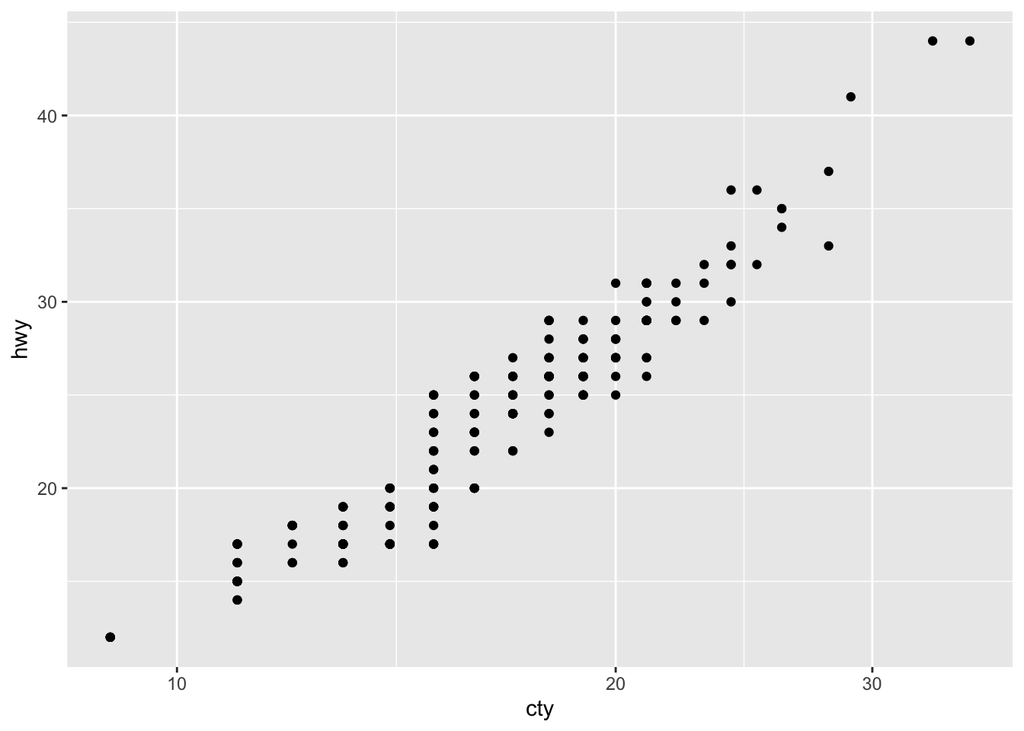

```r
ggplot(mpg, aes(x = cty, y = hwy)) +
  geom_point()

ggplot(mpg, aes(x = cty, y = hwy)) +
  geom_point() +
  scale_x_log10()
```

Ggplot2, establece los límites numéricos de los ejes al determinar el rango de cada un de ellos. Sin embargo, resulta conveniente modificar los limites de los ejes en algunos gráficos. Para ello se utiliza el argumento `limits` dentro de los comandos `scale_x_continous()` y `scale_y_continous()` y los limites se indican como un vector:

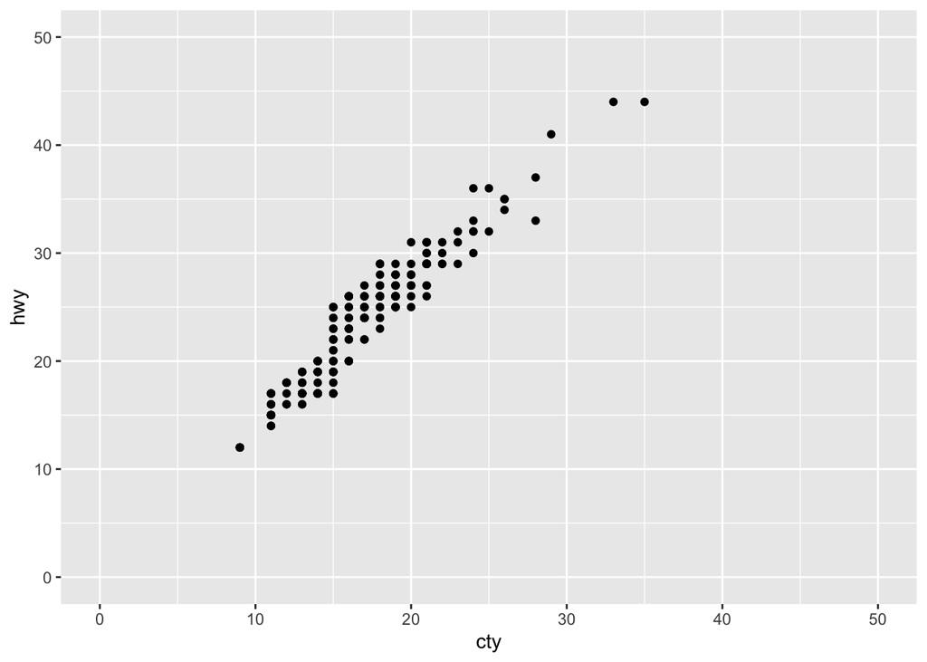

```r
ggplot(mpg, aes(x = cty, y = hwy)) +
  geom_point()

ggplot(mpg, aes(x = cty, y = hwy)) +
  geom_point() +
  scale_x_continuous(limits = c(0, 50)) +
  scale_y_continuous(limits = c(0, 50))
```

En ggplot tambien es posible ajustar las marcas de los ejes *axis breaks*, lo cual es una tarea indispensable para mejorar nuestros gráficos. Dentro de los comandos `scale_x_continous()` y `scale_y_continous()` colocamos el argumento `breaks`:

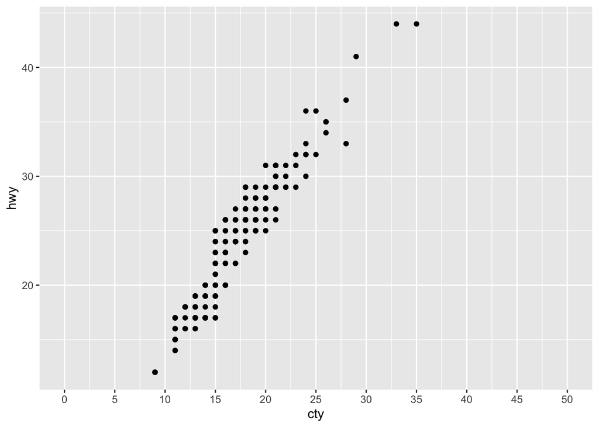

```r
ggplot(mpg, aes(x = cty, y = hwy)) +
  geom_point()

ggplot(mpg, aes(x = cty, y = hwy)) +
  geom_point() +
  scale_x_continuous(breaks = c(0, 5, 10, 15, 20, 25, 30, 35, 40, 45, 50),
                     limits = c(0, 50))
```

> Para colocar secuencias numéricas recuerda utilizar las funciones `seq()` y `sequence()`.

Para un mayor conocimiento de todas las escalas de posición que **`ggplot2`** controla, te recomiendo visitar la página de [https://ggplot2-book.org/scales-position“](https://ggplot2-book.org/scales-position).

### 2.5.2 Escalas de color

Las escalar de color utilizan gradientes que se acoplan de acuerdo a las variables de nuestros datos:

- `scale_fill_continous()` es el comando para generar gradientes de color usando como base variables continuas.
- `scale_fill_discrete()` es el comando para generar gradientes de color usando como base variables categóricas

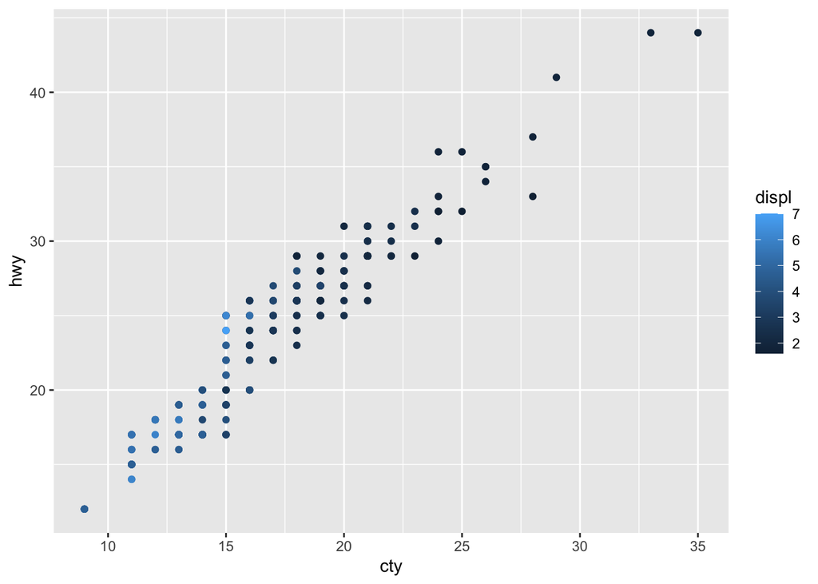

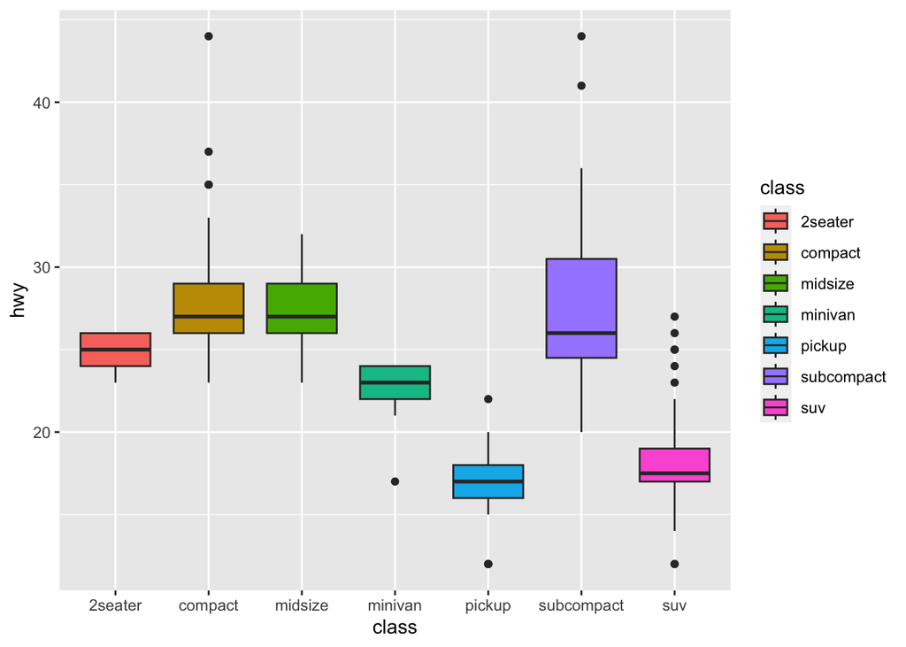

```r
ggplot(mpg, aes(x = cty, y = hwy, color = displ)) +
  geom_point() +
  scale_color_continuous()

ggplot(mpg, aes(x = class, y = hwy, fill = class)) +
  geom_boxplot() +
  scale_fill_discrete()
```

Sin embargo, en ambos casos existen paletas de colores establecidas y que forman parte de los paquetes **`viridis`** y **`RColorBrewer`**.  
**`RColorBrewer`** (Neuwirth 2022)utiliza colores de las paletas de [https://colorbrewer2.org](https://colorbrewer2.org/#type=sequential&scheme=BuGn&n=3). Existen distintas paletas:

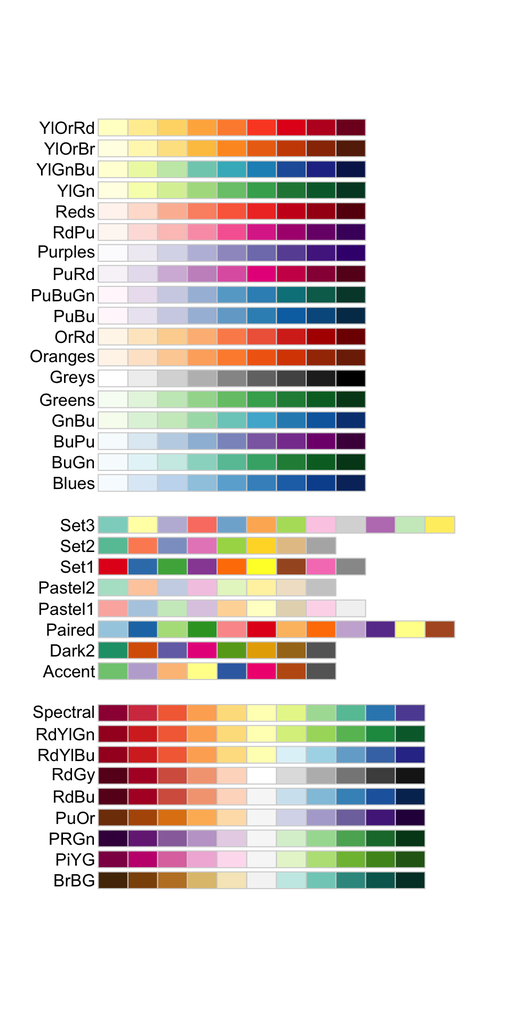

```r
display.brewer.all()
```

Usando el comando `scale_fill_brewer(palette=)` se coloca la capa de color a las graficas:

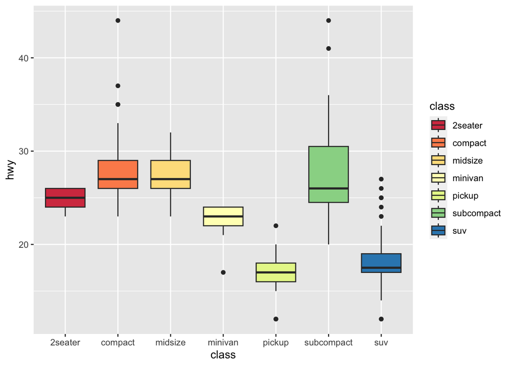

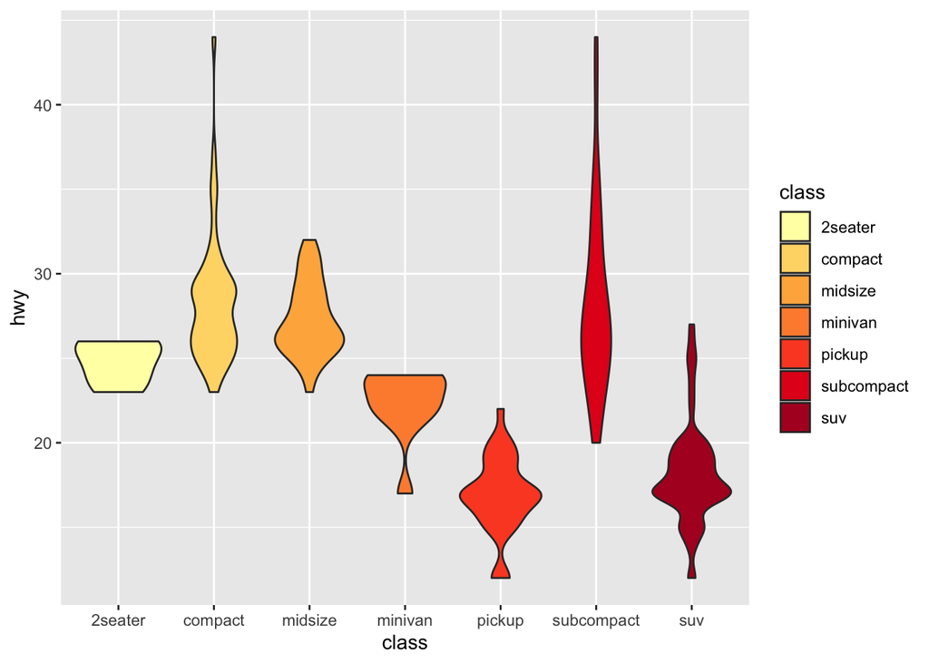

```r
ggplot(mpg, aes(x = class, y = hwy, fill = class)) +
  geom_boxplot() +
  scale_fill_brewer(palette = "Spectral")

ggplot(mpg, aes(x = class, y = hwy, fill = class)) +
  geom_violin() +
  scale_fill_brewer(palette = "YlOrRd")
```

Para variables contínuas, las paletas del paquete **`viridis`** (Garnier et al. 2023)ofrecen una amplia de colores y gradientes:

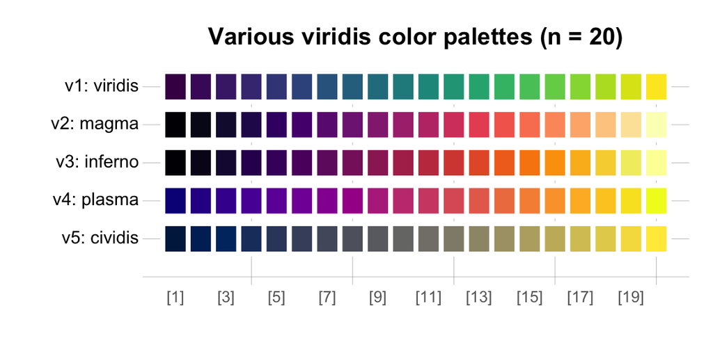

Paletas de colores del paquete viridis. Tomada de https://bookdown.org/hneth/ds4psy/D-4-apx-colors-pkgs.html